# Some Results from the UNOS Data

Fan Wu

2016-11-15

## Data Manipulation

We use the ESRD patients listed for kidney transplantation in 2006 from 40 U.S. states. The *time origin* is set at the ESRD onset, which is the *date of the first renal replacement therapy*, either regulatory dialysis or kidney transplantation. The patients with pre-emptive transplantations are also included. We restriced to the patients who started their first renal replacement therapy after Jan. 1, 2000. The follow-up was until Dec. 4, 2015. The event of interest is *patient death*. We exclude those patients

- first start with dialysis but have no dialysis modality recorded (7%)
- first start with dialysis but have unknown dialysis modality (3%)
- first start with dialysis and change the modality of dialysis before TX (3%)
- first start with dialysis but have no dialysis date recorded (15%)

We allow the renal replacement therapy of a patient change during the follow up, from dialysis to TX after receiving an allograft, or from TX to dialysis following the allograft failure and he/her is on dialysis again. Thus, the treatment is a **time-dependent** covariate.

We also adjusted for age at ESRD onset (YOUNG: 18-40, MIDDLE (ref): 40-60, and OLD: 60+), gender and race.

The number of patients, number of events, and censoring rates for each included states are as follows:

|  | n.Patients | n.Deaths | cens.rate |
| --- | --- | --- | --- |
| CA | 2843 | 835 | 70.6 |
| TX | 1740 | 499 | 71.3 |
| NY | 1559 | 495 | 68.2 |
| PA | 1182 | 452 | 61.8 |
| FL | 1002 | 319 | 68.2 |
| IL | 952 | 339 | 64.4 |
| MI | 761 | 293 | 61.5 |
| OH | 750 | 269 | 64.1 |
| VA | 627 | 256 | 59.2 |
| NC | 534 | 165 | 69.1 |
| TN | 502 | 172 | 65.7 |
| AL | 485 | 215 | 55.7 |
| MN | 473 | 152 | 67.9 |
| NJ | 469 | 171 | 63.5 |
| GA | 459 | 134 | 70.8 |
| AZ | 425 | 121 | 71.5 |
| MA | 423 | 151 | 64.3 |
| MO | 414 | 122 | 70.5 |
| MD | 367 | 127 | 65.4 |
| WI | 345 | 113 | 67.2 |
| LA | 321 | 109 | 66.0 |
| IN | 308 | 94 | 69.5 |
| CO | 274 | 98 | 64.2 |
| WA | 271 | 76 | 72.0 |
| DC | 248 | 75 | 69.8 |
| OR | 200 | 68 | 66.0 |
| KY | 179 | 67 | 62.6 |
| OK | 137 | 55 | 59.9 |
| UT | 137 | 31 | 77.4 |
| SC | 135 | 43 | 68.1 |
| AR | 134 | 52 | 61.2 |
| NE | 131 | 44 | 66.4 |
| CT | 116 | 32 | 72.4 |
| IA | 114 | 43 | 62.3 |
| KS | 101 | 30 | 70.3 |
| NM | 80 | 26 | 67.5 |
| NV | 80 | 26 | 67.5 |
| ME | 69 | 23 | 66.7 |
| ND | 66 | 20 | 69.7 |
| WV | 62 | 29 | 53.2 |

## Estimate of the PD and TX log Hazards

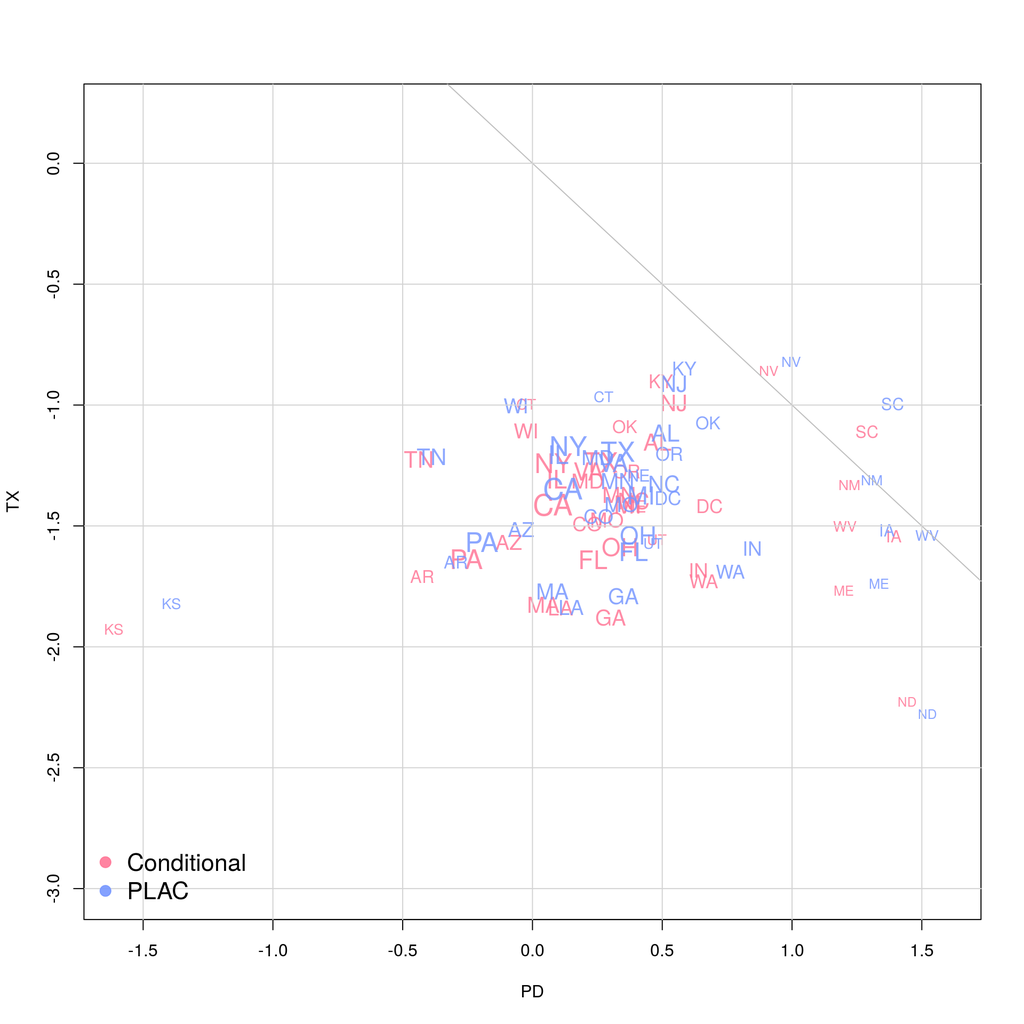

## Estimate of the YOUNG and OLD log Hazards

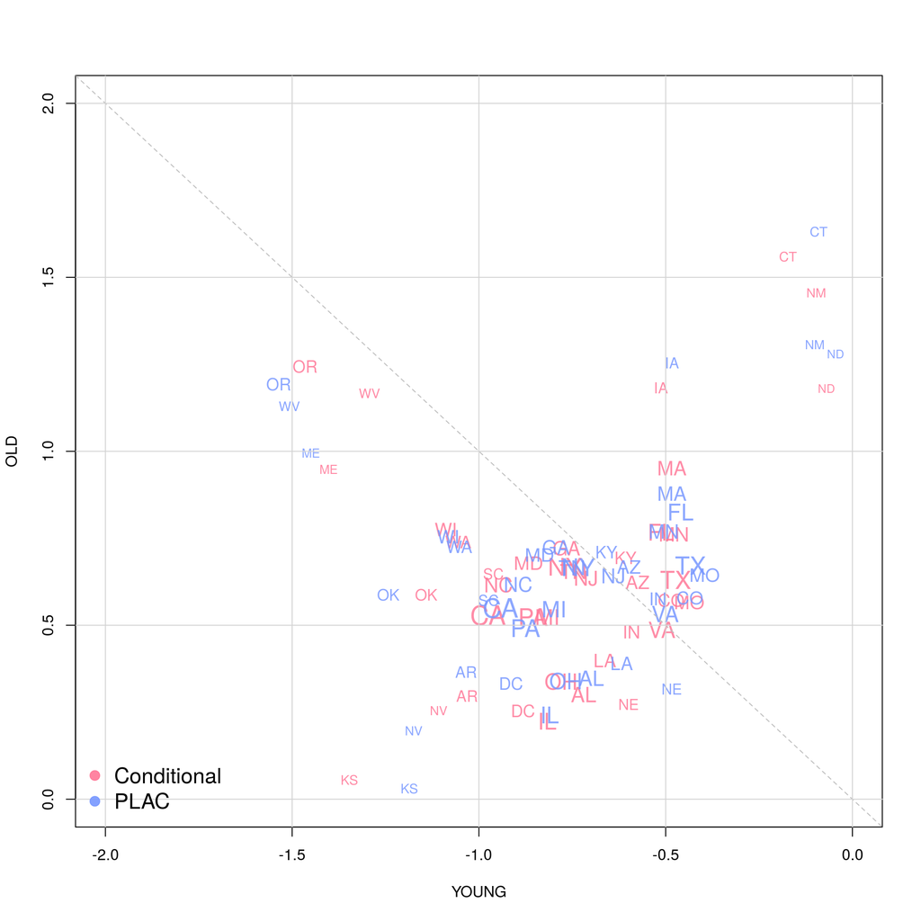

## Compare SEs using Conditional vs PLAC

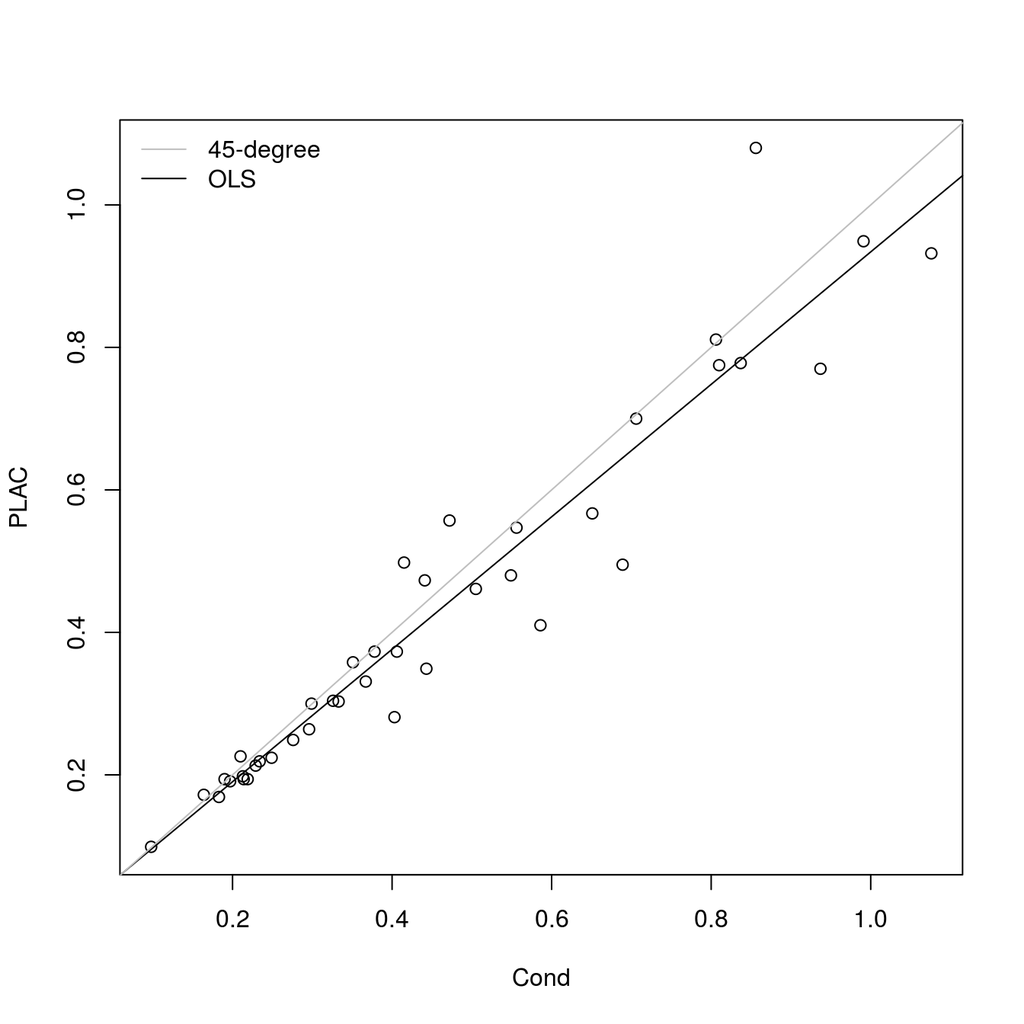

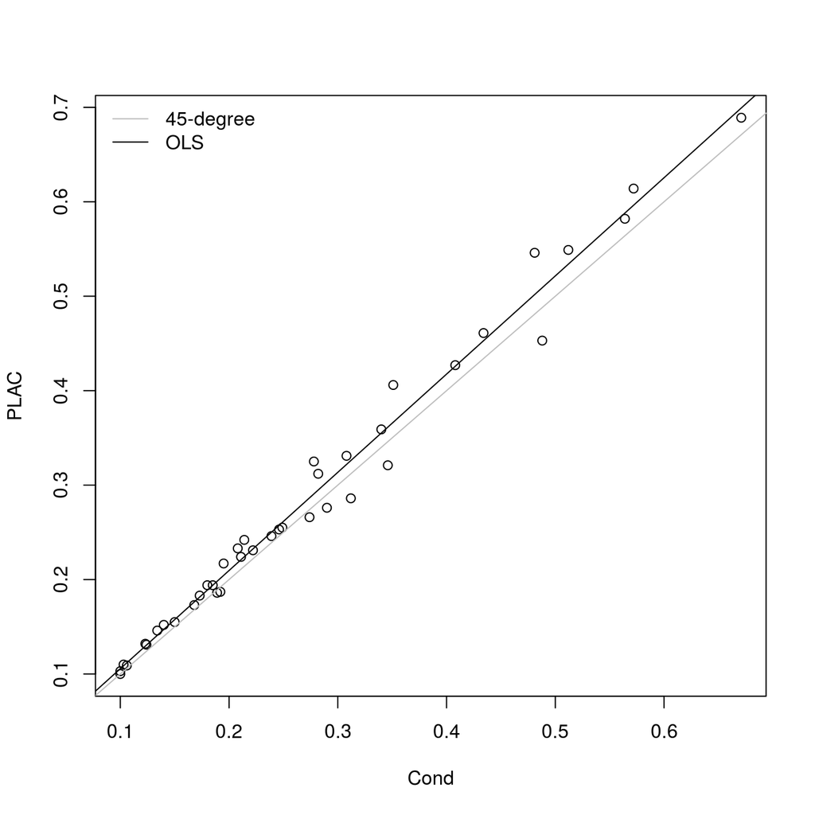

## Compare Ratio of Variances using Conditional vs PLAC

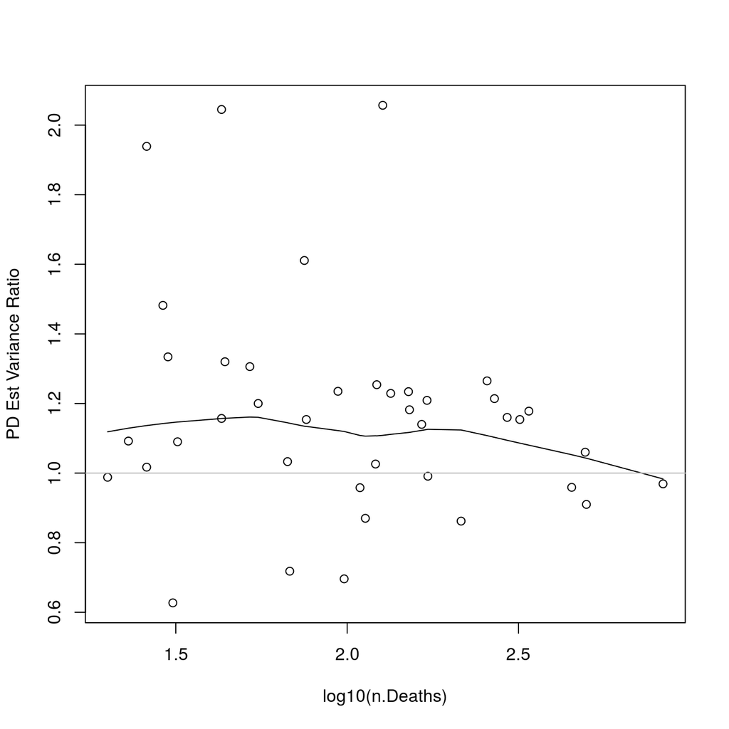

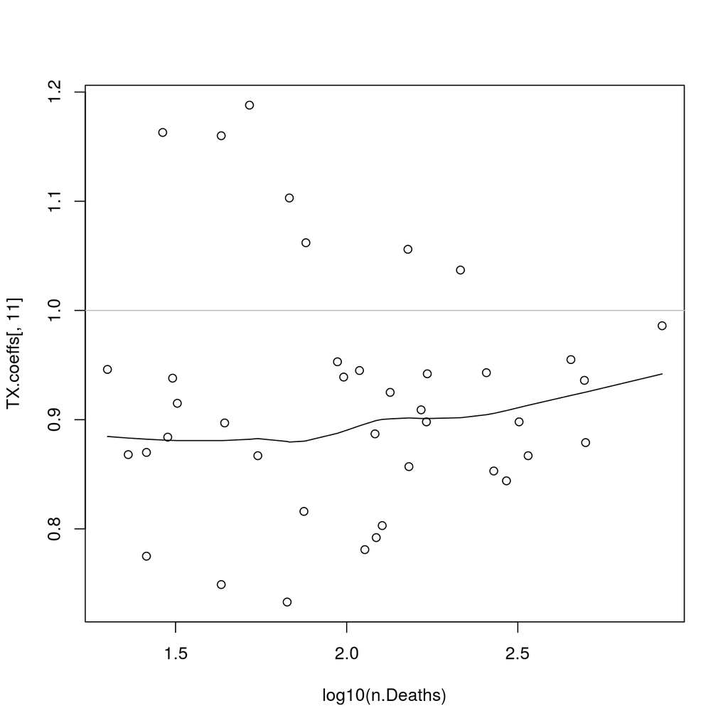

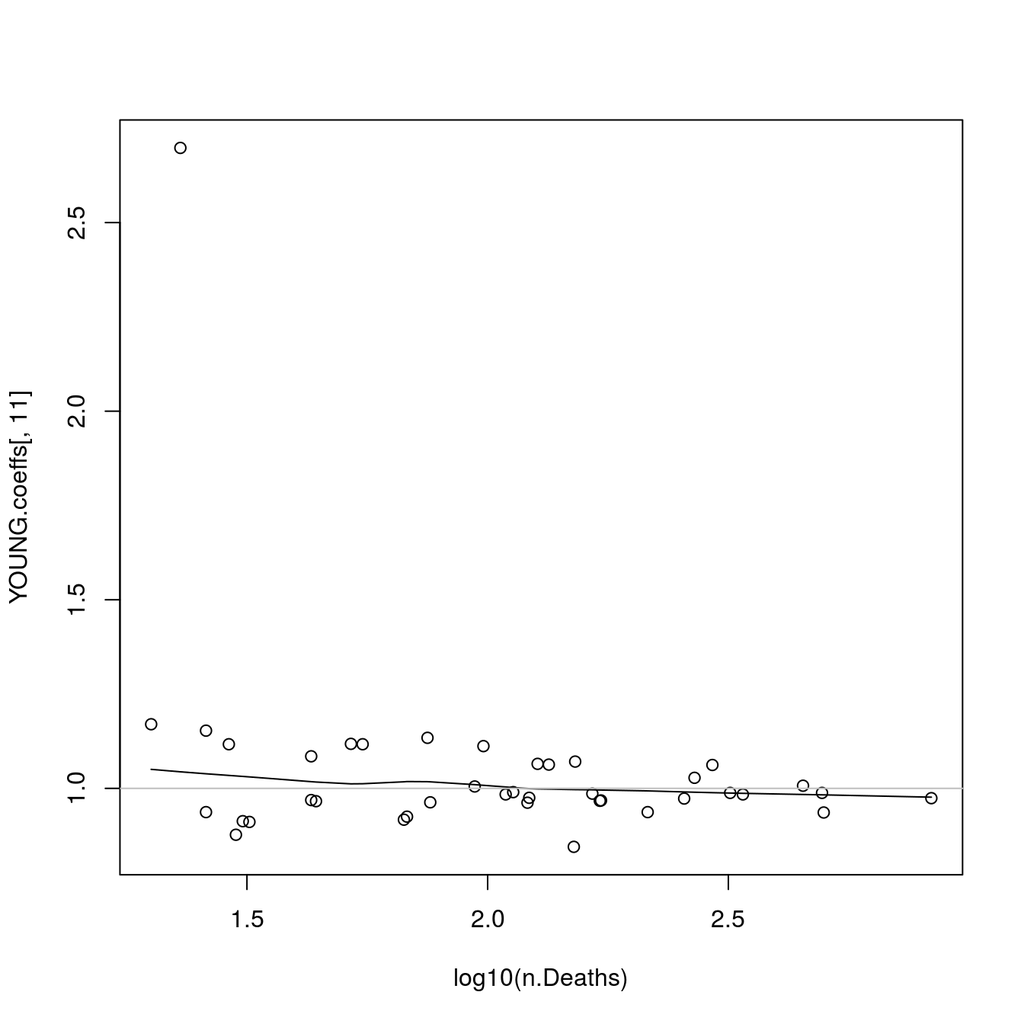

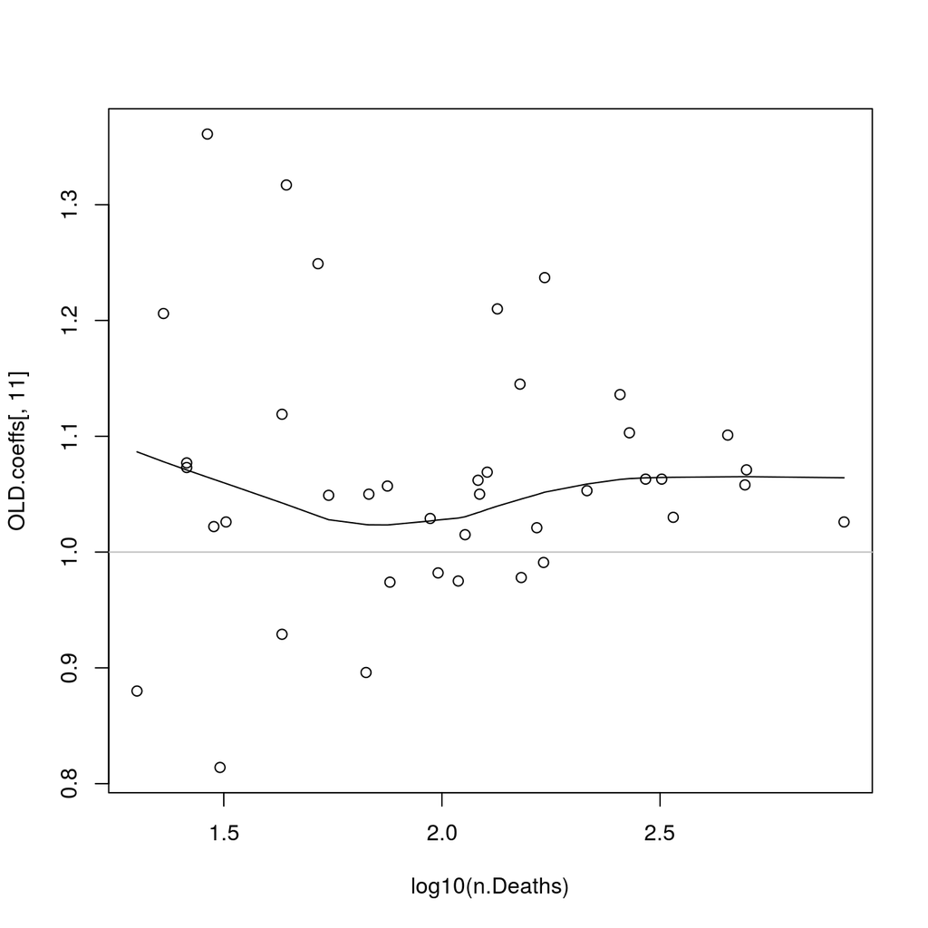

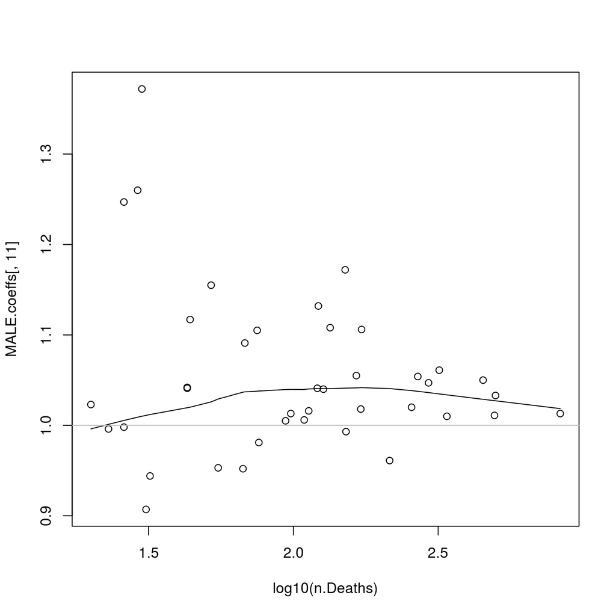

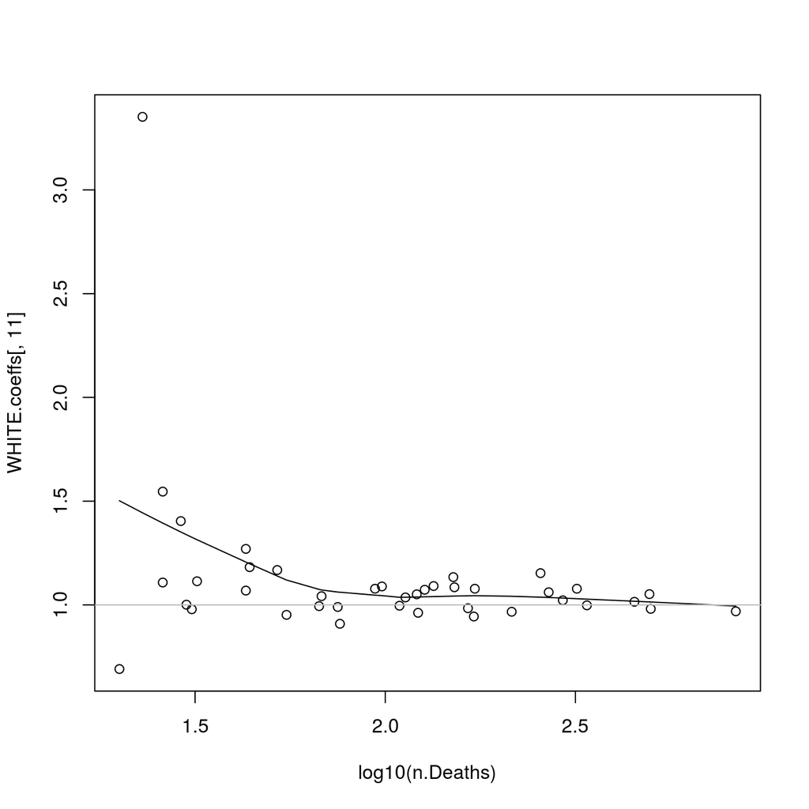

## Christmas Trees

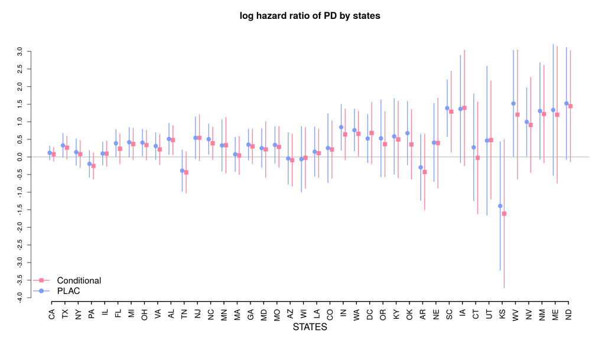

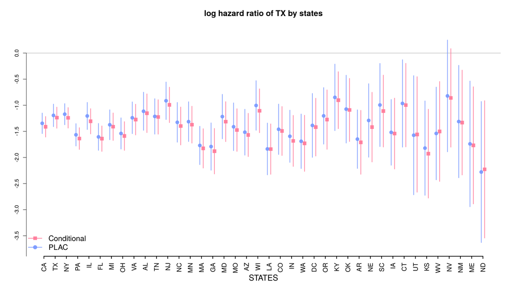

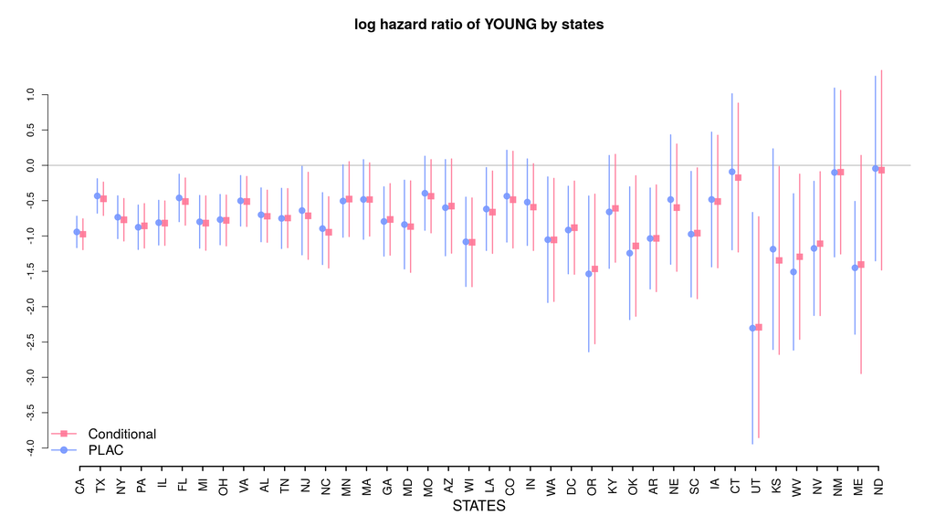

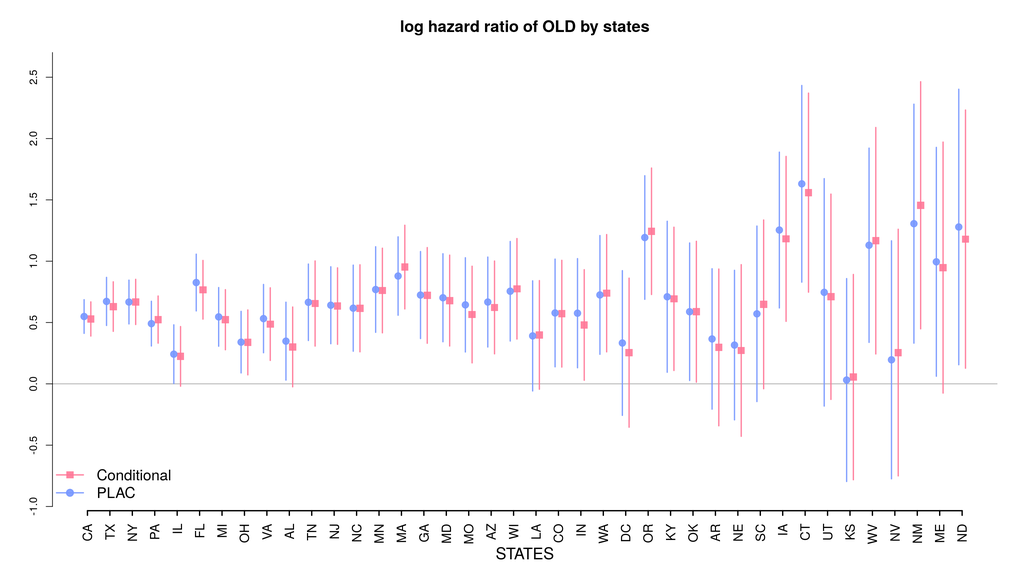

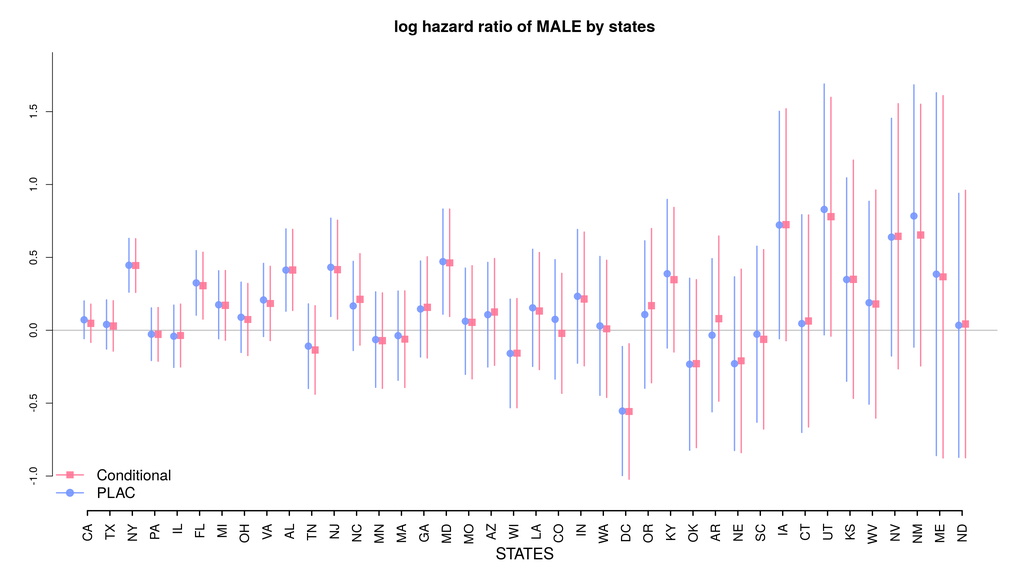

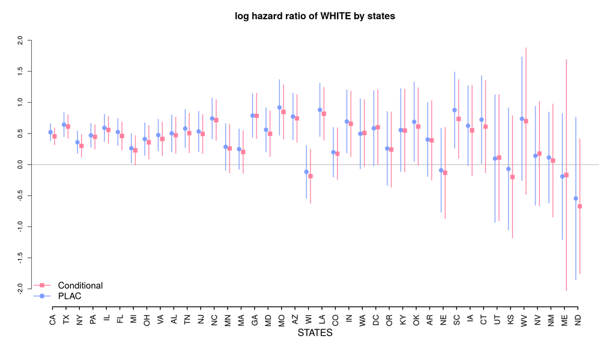

## To Make the Analysis Great Again

- Change the time point of switching the “on-going” treatment (e.g., 60 days after the switch)